# Part_8_Basic_EDA_Project

## Relationships and Multi-Variable Plots

A big part of exploratory data analysis is seeing how mutliple variables are related. We can use multiple different types of plots to easily see these relationships. By understanding these relationships we can start to understand which features may be releated or can serve to predict others. In this part we will explore:

1. Scatter plots
2. Correlation Matrices
3. Pivot Tables
4. Bar Charts
5. Line Charts

### Scatter Plots

We use these to see if there is a relationship between two datapoints.

Let's take a look at a few variables and see if they may be correlated. We will explore if the average percentage viewed of the video is related to the cost per milli on the video (the amount youtube makes for 1000 views)

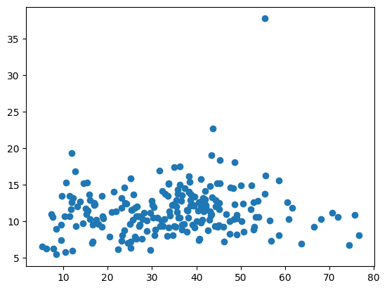

```python
#create plot with matplotlib
plt.scatter(df_agg['Average percentage viewed (%)'] ,df_agg['CPM (USD)'])
```

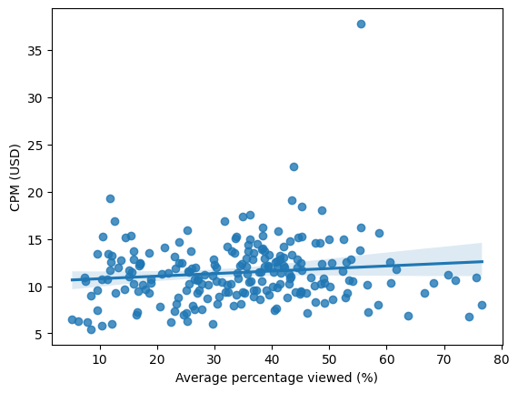

```python
#let's do the same thing with seaborn so we can see a trendline. This will be easier for us to build multiple of these
sns.regplot(x='Average percentage viewed (%)',y='CPM (USD)', data = df_agg)

#as we can see there is a very little correlation between the two variables
```

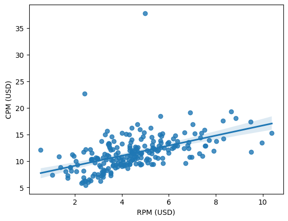

```python
#Let's try another. How do variables RPM and CPM match up. RPM is how much the youtuber makes for an add. Again CPM is how much youtube sells the ad for.
sns.regplot(x='RPM (USD)',y='CPM (USD)', data = df_agg)

# Here we can see a lot stronger relationship between the two rates. These are the types of insights you can find in these graphs
```

### Correlation Matrices

Scatter plots are great for comparing two variables. Often we have many different variables that we want to see relationships between.

In this case we would use a correlation matrix. Let's do a correlation matrix for all of our value in the dataset.

```python
df_agg_corr = df_agg.select_dtypes(exclude='object')
df_agg_corr = df_agg_corr.drop(columns=['rev_buckets'])
```

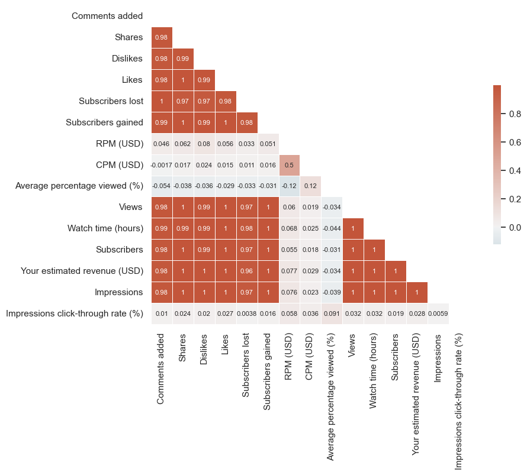

```python
#first, we get the correlations between our datapoints. We can see all the relationships that will be polotted via the pearson correlation coefficient
# Compute the correlation matrix
corr = df_agg_corr.select_dtypes(exclude='object').corr()


sns.set_theme(style="white")

# Generate a mask for the upper triangle (otherwise this looks like the square we had above and is redundant)
mask = np.triu(np.ones_like(corr, dtype=bool))

# Set up the matplotlib figure
f, ax = plt.subplots(figsize=(10, 7))

# Generate a custom diverging colormap (choose colors here)
cmap = sns.diverging_palette(230, 20, as_cmap=True)

# Draw the heatmap with the mask and correct aspect ratio
sns.heatmap(corr, mask=mask, cmap=cmap, center=0,
            square=True, linewidths=.5, cbar_kws={"shrink": .5}, annot=True, annot_kws={"fontsize":8});

#obviously many of thes variables are HIGHLY correlated. Something we may want to explore is why Average percentage viewed is negatively related to RPM
```

### Pivot Tables

Sometimes we want to cut the data and compare how variables stack up. For example we may want to see which countries have the highest view duration. We can do this easily with pivot tables.

We will use the df_agg_country_sub dataset to explore this.

```python
#pivot table to explore values. A basic pivot table takes the average of these different categories we choose.

pd.pivot_table(df_agg_country_sub, index = 'Country Code', values = 'Average View Percentage')
```

| Country Code | Average View Percentage |
| --- | --- |
| AD | 0.346120 |
| AE | 0.337669 |
| AF | 0.268558 |
| AG | 0.387360 |
| AI | 0.131323 |
| ... | ... |
| YT | 0.079946 |
| ZA | 0.405515 |
| ZM | 0.394836 |
| ZW | 0.409843 |
| ZZ | 0.290313 |

232 rows × 1 columns

```python
#this time, let's compare average view percentage by country code and subscriber status.
pd.pivot_table(df_agg_country_sub, index = 'Country Code', columns = 'Is Subscribed',values = 'Average View Percentage')

#we could plot this to see which countries have the biggest difference in subscribed watch time for subscribed vs not subscribed viewers
```

| Is Subscribed Country Code | False | True |
| --- | --- | --- |
| AD | 0.380891 | 0.264160 |
| AE | 0.332929 | 0.342343 |
| AF | 0.233260 | 0.314174 |
| AG | 0.352685 | 0.435457 |
| AI | 0.131323 | NaN |
| ... | ... | ... |
| YT | 0.086662 | 0.012785 |
| ZA | 0.385556 | 0.425383 |
| ZM | 0.339654 | 0.454055 |
| ZW | 0.379156 | 0.439400 |
| ZZ | 0.227364 | 0.353262 |

232 rows × 2 columns

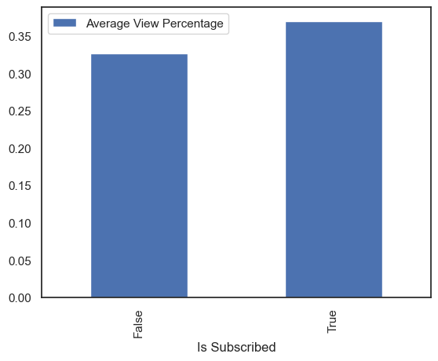

```python
#Let's plot a slightly simpler graph. Let's just look at if subscribers or non-subsribers watch videos for longer
pd.pivot_table(df_agg_country_sub, index = 'Is Subscribed', values = 'Average View Percentage').plot.bar()
```